# Homework DV5

Ayanna Chatman

2023-10-05

```r
library(tidyverse)
wncaa <- read.csv("https://raw.githubusercontent.com/vaiseys/dav-course/main/Data/wncaa.csv")
```

## Question 1

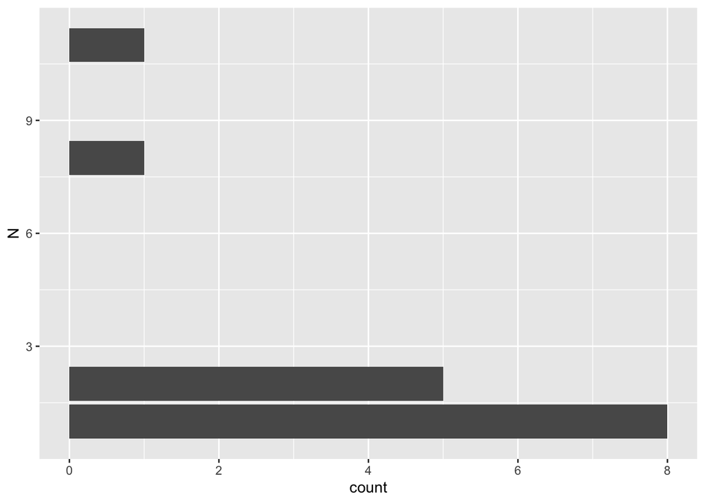

```r
tourney_champ <- wncaa %>%
  filter(tourney_finish == "Champ") %>%
  group_by(school) %>%
  summarise(N = n()) %>%
  mutate(freq = N/ sum(N))

ggplot(data = tourney_champ,
       mapping = aes(x = N)) +
  geom_bar() +
  coord_flip()
```

The teams that have won the most tourneys are Tennessee and UConn.

## Question 2

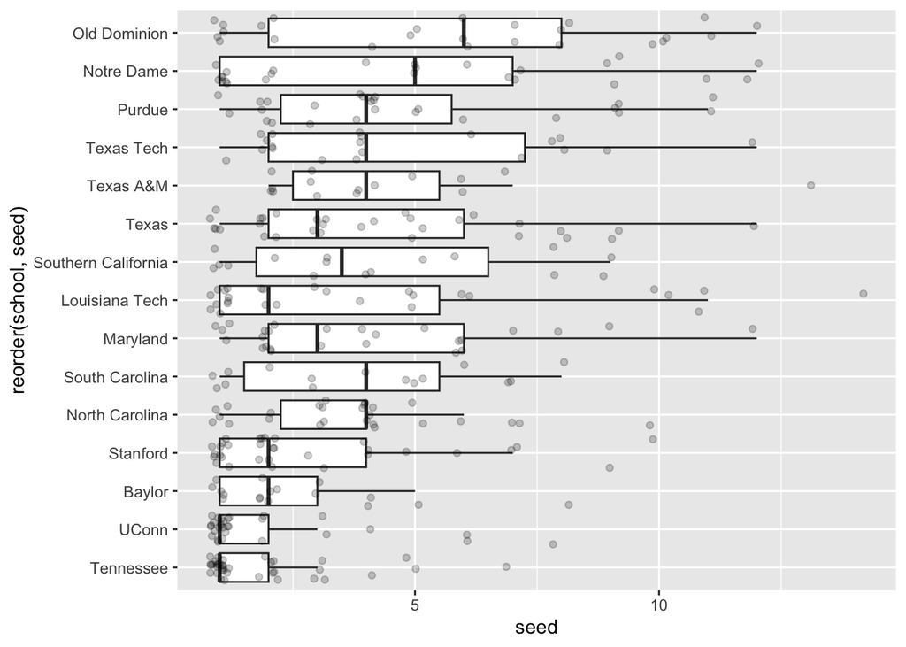

```r
champ_names <- unique(tourney_champ$school)

winners <- wncaa %>%
  filter(school %in% champ_names)

ggplot(data = winners,
       mapping = aes(x = seed,
                     y = reorder(school, seed))) +
  geom_boxplot(outlier.shape = NA) +
  geom_jitter(width = .2, alpha = .2)
```

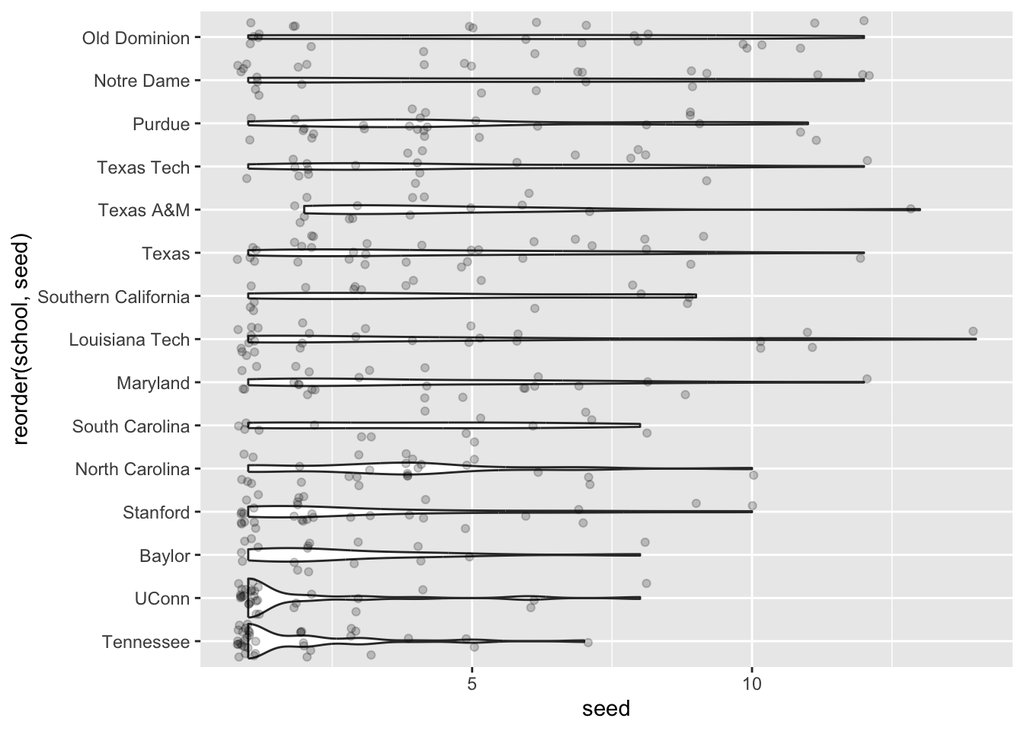

```r
champ_names <- unique(tourney_champ$school)

winners <- wncaa %>%
  filter(school %in% champ_names)

ggplot(data = winners,
       mapping = aes(x = seed,
                     y = reorder(school, seed))) +
  geom_violin(outlier.shape = NA) +
  geom_jitter(width = .2, alpha = .2)
```

## Question 3

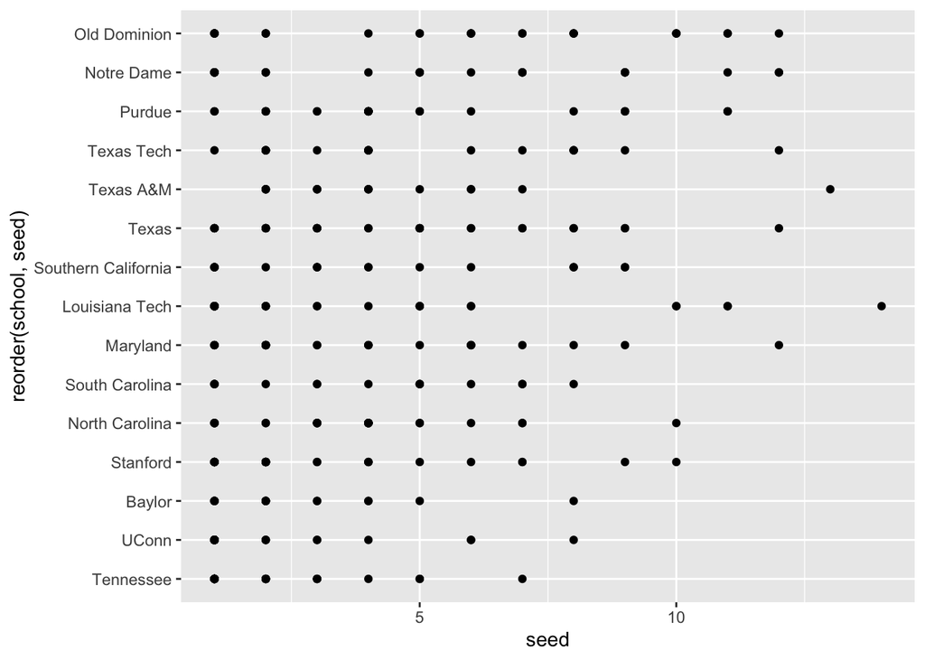

```r
champ_names <- unique(tourney_champ$school)

winners <- wncaa %>%
  filter(school %in% champ_names)

ggplot(data = winners,
       mapping = aes(x = seed,
                     y = reorder(school, seed))) +
  geom_point(outlier.shape = NA)
```

Geom_point doesn’t work very well because it doesn’t show good representation of how different and how freqeuntly the different schools have been in the seed rankings.

## Question 4

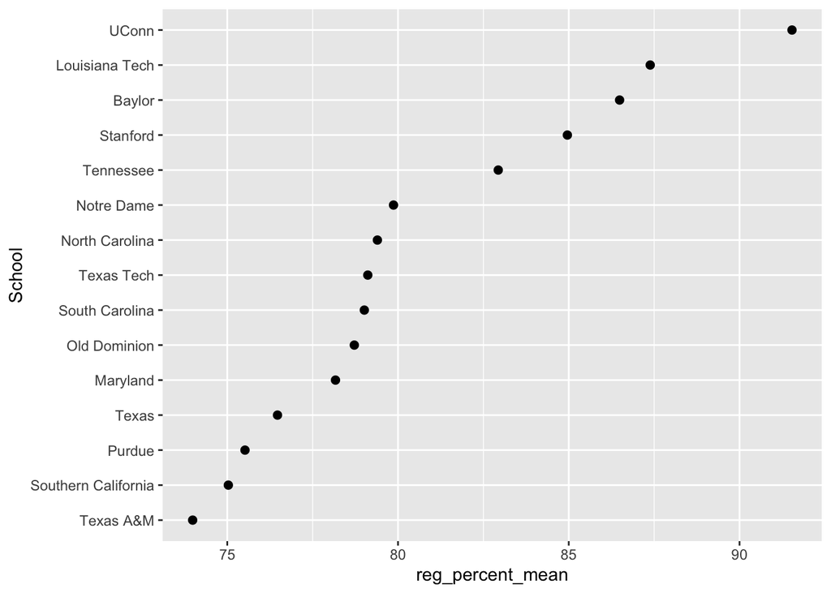

```r
winners_mean_sd <- winners %>%
  group_by(school) %>%
  summarize(across(where(is.numeric),
                   list(mean = mean,
                        sd = sd)))

ggplot(data = winners_mean_sd,
       mapping = aes(x = reorder(school, reg_percent_mean),
         y = reg_percent_mean)) +
  geom_point(size = 2, width = .2) +
  coord_flip() +
  labs( x = "School")
```

Texas, Purdue, USC, and Texas A&M have the lowest regualr seaons win average. Norte Dame, NC, Texas Tech, SC, Old Dominion, and Maryland’s regular season win average results are in the middle of the dataset. Tennessee, Stanford, Baylor, Louisiana Tech, and Uconn have the highest regular season win average. The results show that Uconn has the highest regular seasons win average across the seasons, and Texas A&M has the lowest. UConn is a bit of an outlier in this data set.

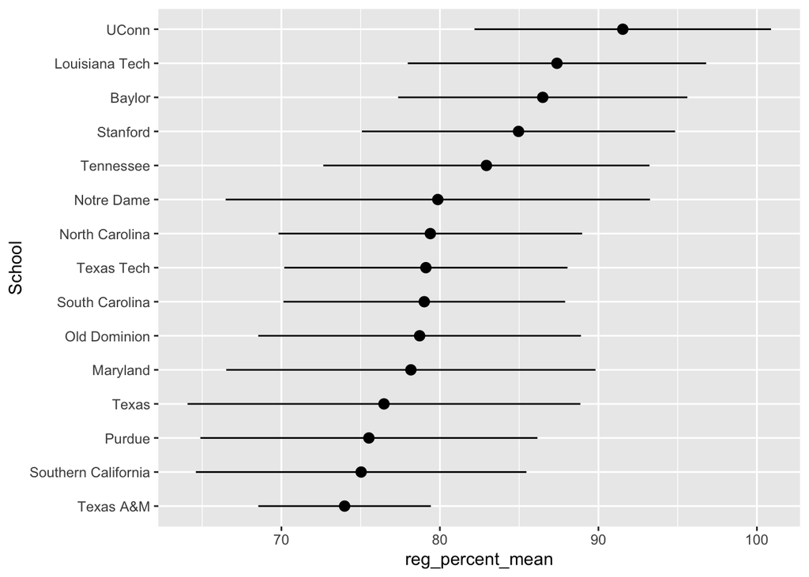

```r
winners_mean_sd <- winners %>%
  group_by(school) %>%
  summarize(across(where(is.numeric),
                   list(mean = mean,
                        sd = sd)))

ggplot(data = winners_mean_sd,
       mapping = aes(x = reorder(school, reg_percent_mean),
         y = reg_percent_mean)) +
  geom_pointrange(mapping = aes(ymin = reg_percent_mean - reg_percent_sd,
                                ymax = reg_percent_mean + reg_percent_sd)) +
  coord_flip() +
  labs( x = "School")
```

Texas A&M has the narrowest interval meaning they had the smallest standard deviation.

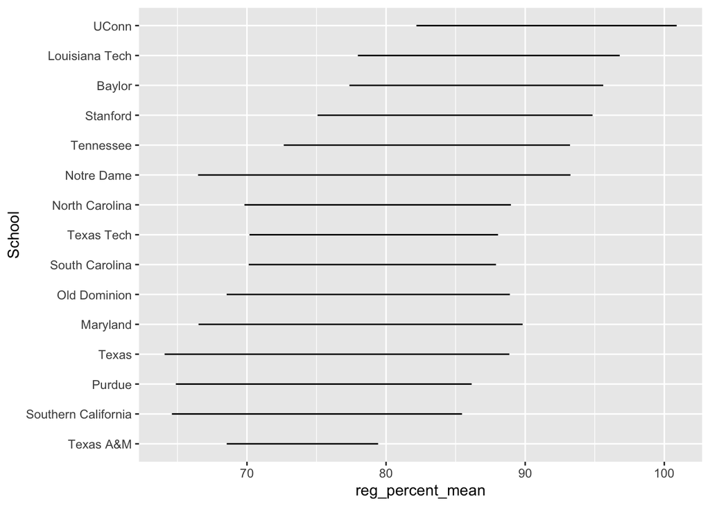

```r
winners_mean_sd <- winners %>%
  group_by(school) %>%
  summarize(across(where(is.numeric),
                   list(mean = mean,
                        sd = sd)))

ggplot(data = winners_mean_sd,
       mapping = aes(x = reorder(school, reg_percent_mean),
         y = reg_percent_mean)) +
  geom_linerange(mapping = aes(ymin = reg_percent_mean - reg_percent_sd,
                                ymax = reg_percent_mean + reg_percent_sd)) +
  coord_flip() +
  labs( x = "School")
```